# Machine Learning project

thibault nidelet

8 juin 2016

# Background and Objective

Using devices such as Jawbone Up, Nike FuelBand, and Fitbit it is now possible to collect a large amount of data about personal activity relatively inexpensively. These type of devices are part of the quantified self movement of a group of enthusiasts who take measurements about themselves regularly to improve their health, to find patterns in their behavior, or because they are tech geeks. One thing that people regularly do is quantify how much of a particular activity they do, but they rarely quantify how well they do it. In this project, your goal will be to use data from accelerometers on the belt, forearm, arm, and dumbell of 6 participants. They were asked to perform barbell lifts correctly and incorrectly in 5 different ways.

## Data

The training data for this project are available here: https://d396qusza40orc.cloudfront.net/predmachlearn/pml-training.csv

The test data are available here: https://d396qusza40orc.cloudfront.net/predmachlearn/pml-testing.csv

# Data Processing

We first going to download the dataset and look at it. There is a lot of columns that are not informative for us and others with a lot of NA or empty information. So we going to clean the two dataset previously to make any analysis.

```r
library(caret)
to_train <- read.csv("https://d396qusza40orc.cloudfront.net/predmachlearn/pml-training.csv",header=T,sep=",")
testing <- read.csv("https://d396qusza40orc.cloudfront.net/predmachlearn/pml-testing.csv",header=T,sep=",")

to_train <- to_train[, 6:dim(to_train)[2]]
testing <- testing[, 6:dim(testing)[2]]

treshold <- dim(to_train)[1]*0.90
goodColumns <- !apply(to_train, 2, function(x) sum(is.na(x))>treshold | sum(x=="")>treshold)
to_train <- to_train[, goodColumns]
testing <- testing[, goodColumns]

badColumns <- nearZeroVar(to_train, saveMetrics = TRUE)
to_train <- to_train[, badColumns$nzv==FALSE]
testing <- testing[, badColumns$nzv==FALSE]

str(to_train)
```

```
## 'data.frame':    19622 obs. of  54 variables:
##  $ num_window          : int  11 11 11 12 12 12 12 12 12 12 ...
##  $ roll_belt           : num  1.41 1.41 1.42 1.48 1.48 1.45 1.42 1.42 1.43 1.45 ...
##  $ pitch_belt          : num  8.07 8.07 8.07 8.05 8.07 8.06 8.09 8.13 8.16 8.17 ...
##  $ yaw_belt            : num  -94.4 -94.4 -94.4 -94.4 -94.4 -94.4 -94.4 -94.4 -94.4 -94.4 ...
##  $ total_accel_belt    : int  3 3 3 3 3 3 3 3 3 3 ...
##  $ gyros_belt_x        : num  0 0.02 0 0.02 0.02 0.02 0.02 0.02 0.02 0.03 ...
##  $ gyros_belt_y        : num  0 0 0 0 0.02 0 0 0 0 0 ...
##  $ gyros_belt_z        : num  -0.02 -0.02 -0.02 -0.03 -0.02 -0.02 -0.02 -0.02 -0.02 0 ...
##  $ accel_belt_x        : int  -21 -22 -20 -22 -21 -21 -22 -22 -20 -21 ...
##  $ accel_belt_y        : int  4 4 5 3 2 4 3 4 2 4 ...
##  $ accel_belt_z        : int  22 22 23 21 24 21 21 21 24 22 ...
##  $ magnet_belt_x       : int  -3 -7 -2 -6 -6 0 -4 -2 1 -3 ...
##  $ magnet_belt_y       : int  599 608 600 604 600 603 599 603 602 609 ...
##  $ magnet_belt_z       : int  -313 -311 -305 -310 -302 -312 -311 -313 -312 -308 ...
```

[output cut: 40 more lines]

```r
table(to_train$classe)
```

```
##
##    A    B    C    D    E
## 5580 3797 3422 3216 3607
```

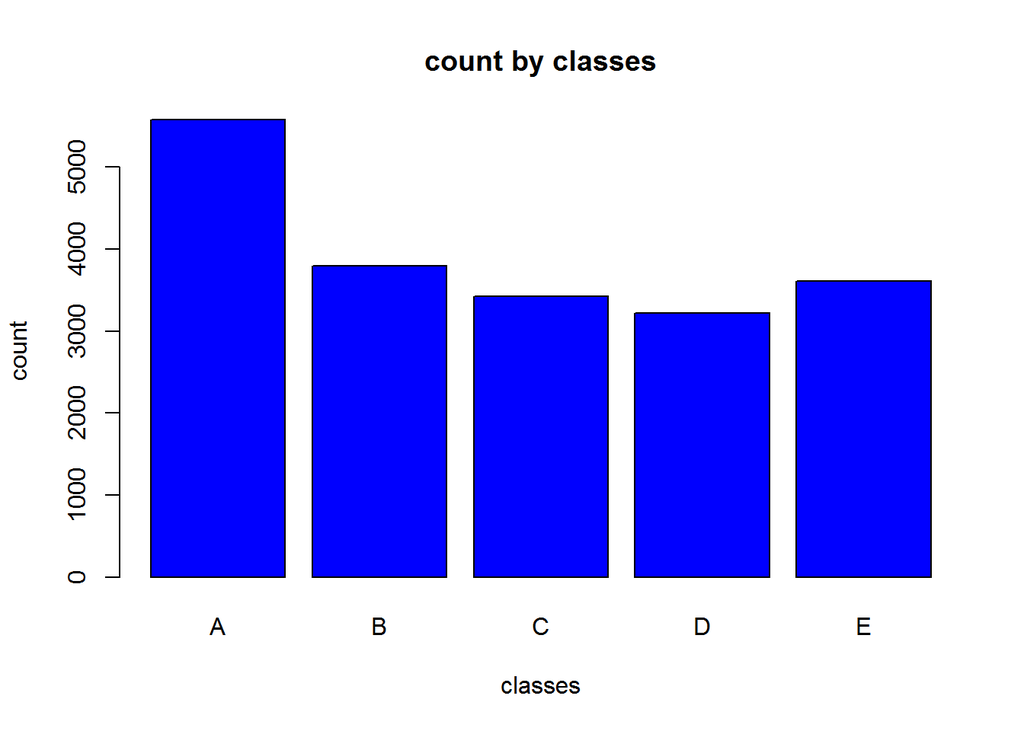

```r
barplot(table(to_train$classe),ylab="count",xlab="classes",col="blue",main="count by classes")
```

The data appears to be in a proper form.

# Create `training` and `validation` sets

With the `caret` package we going to split our `to_train` dataset into two smaller dataset : `training` and `validation`. We will fit the model on the `training` dataset and test it in the `validation` set.

```r
library(caret)

# Create a building data set and validation set
set.seed(333)
inBuild <- createDataPartition(y=to_train$classe,p=0.7, list=FALSE)
validation <- to_train[-inBuild,]
training <- to_train[inBuild,]

dim(training)
```

```
## [1] 13737    54
```

```r
dim(validation)
```

```
## [1] 5885   54
```

```r
dim(testing)
```

```
## [1] 20 54
```

# Machine learning

We going to test two different machine learning strategy : `random forest` and `boosting`. We will choose the model that best predict the `classe` on the `validation` dataset.

```r
mod_rf <- train(classe ~ ., data=training, method="rf")
mod_gbm <- train(classe ~ ., data=training, method="gbm",verbose=FALSE)

pred_rf <- predict(mod_rf,validation)
confusionMatrix(pred_rf, validation$classe)
```

```
## Confusion Matrix and Statistics
##
##           Reference
## Prediction    A    B    C    D    E
##          A 1674    4    0    0    0
##          B    0 1135    1    0    0
##          C    0    0 1025    3    0
##          D    0    0    0  961    5
##          E    0    0    0    0 1077
##
## Overall Statistics
##
##                Accuracy : 0.9978
##                  95% CI : (0.9962, 0.9988)
##     No Information Rate : 0.2845
##     P-Value [Acc > NIR] : < 2.2e-16
##
##                   Kappa : 0.9972
##  Mcnemar's Test P-Value : NA
##
## Statistics by Class:
##
##                      Class: A Class: B Class: C Class: D Class: E
## Sensitivity            1.0000   0.9965   0.9990   0.9969   0.9954
## Specificity            0.9991   0.9998   0.9994   0.9990   1.0000
## Pos Pred Value         0.9976   0.9991   0.9971   0.9948   1.0000
## Neg Pred Value         1.0000   0.9992   0.9998   0.9994   0.9990
## Prevalence             0.2845   0.1935   0.1743   0.1638   0.1839
## Detection Rate         0.2845   0.1929   0.1742   0.1633   0.1830
## Detection Prevalence   0.2851   0.1930   0.1747   0.1641   0.1830
## Balanced Accuracy      0.9995   0.9981   0.9992   0.9979   0.9977
```

```r
pred_gbm <- predict(mod_gbm,validation)
confusionMatrix(pred_gbm, validation$classe)
```

```
## Confusion Matrix and Statistics
##
##           Reference
## Prediction    A    B    C    D    E
##          A 1672   12    0    0    0
##          B    2 1112    5    0    5
##          C    0   15 1012   11    1
##          D    0    0    9  951   18
##          E    0    0    0    2 1058
##
## Overall Statistics
##
##                Accuracy : 0.9864
##                  95% CI : (0.9831, 0.9892)
##     No Information Rate : 0.2845
##     P-Value [Acc > NIR] : < 2.2e-16
##
##                   Kappa : 0.9828
##  Mcnemar's Test P-Value : NA
##
## Statistics by Class:
##
##                      Class: A Class: B Class: C Class: D Class: E
## Sensitivity            0.9988   0.9763   0.9864   0.9865   0.9778
## Specificity            0.9972   0.9975   0.9944   0.9945   0.9996
## Pos Pred Value         0.9929   0.9893   0.9740   0.9724   0.9981
## Neg Pred Value         0.9995   0.9943   0.9971   0.9974   0.9950
## Prevalence             0.2845   0.1935   0.1743   0.1638   0.1839
## Detection Rate         0.2841   0.1890   0.1720   0.1616   0.1798
## Detection Prevalence   0.2862   0.1910   0.1766   0.1662   0.1801
## Balanced Accuracy      0.9980   0.9869   0.9904   0.9905   0.9887
```

```r
sum(pred_rf==validation$classe)/length(pred_rf)
```

```
## [1] 0.997791
```

```r
sum(pred_gbm==validation$classe)/length(pred_gbm)
```

```
## [1] 0.9864061
```

The two methods are very effctive and predict the same thing in 99% of cases. However the random forest strategy give the best results with 0.997791 accuracy. So we going to used it to predict the classes for the `testing` dataset.

We also going to look at the 20 most important variables that are used to predict the classe in the random forest.

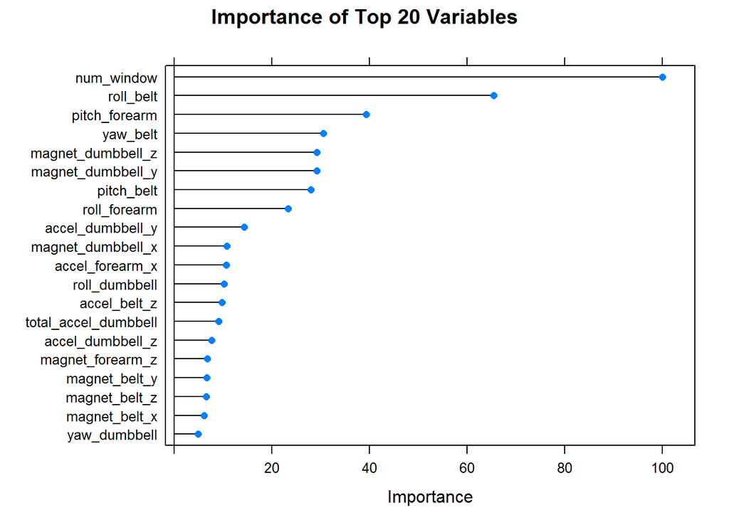

```r
plot(varImp(mod_rf), main = "Importance of Top 20 Variables", top = 20)
```

# Predicting the value for the testing set.

```r
final_pred <- predict(mod_rf, newdata=testing)
final_pred
```

```
##  [1] B A B A A E D B A A B C B A E E A B B B
## Levels: A B C D E
```

The data for this project come from this source: http://groupware.les.inf.puc-rio.br/har.